# Parental Investment Strategies in Avian Care

## B. Efficiency Analysis (Complex Visualization)

Does spending more time foraging result in a larger food reward? We visualize this relationship using a scatterplot with best-fit lines.

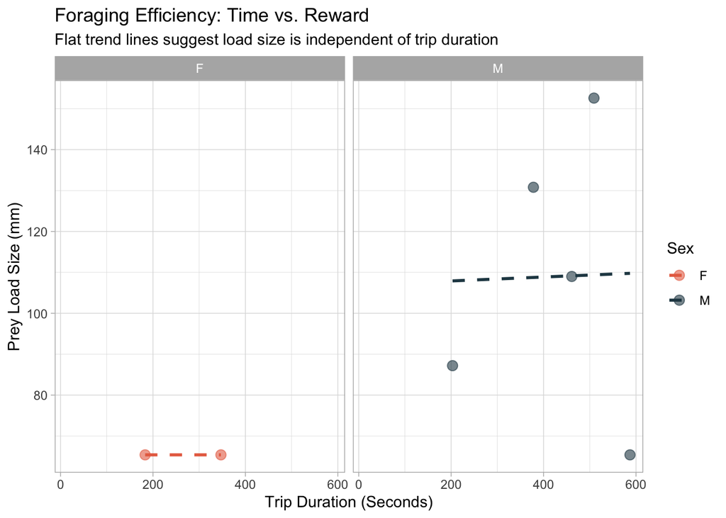

```r
# Chart 2: Scatterplot with Faceting
ggplot(birds_clean, aes(x = TripSec, y = Loadmm, color = Sex)) +
  geom_point(alpha = 0.6, size = 3) +
  geom_smooth(method = "lm", se = FALSE, linetype = "dashed") +
  facet_wrap(~Sex) + # Faceting separates the trends
  scale_color_manual(values = c("F" = "#E76F51", "M" = "#264653")) +
  labs(
    title = "Foraging Efficiency: Time vs. Reward",
    subtitle = "Flat trend lines suggest load size is independent of trip duration",
    x = "Trip Duration (Seconds)",
    y = "Prey Load Size (mm)"
  ) +
  theme_light()
```

# 3. Statistical Inference (Portfolio Analysis)

Visualizations suggest differences, but are they **statistically significant**? Here we apply inferential statistics to validate our observations.

## A. Outlier Analysis (IQR Method)

Biological data is often noisy. We check for outliers in `TripSec` that might skew our mean calculations.

```r
# Calculate IQR boundaries
trip_stats <- birds_clean %>%
  summarize(
    Q1 = quantile(TripSec, 0.25),
    Q3 = quantile(TripSec, 0.75),
    IQR = IQR(TripSec)
  )

lower_bound <- trip_stats$Q1 - 1.5 * trip_stats$IQR
upper_bound <- trip_stats$Q3 + 1.5 * trip_stats$IQR

# Identify Outliers
outliers <- birds_clean %>%
  filter(TripSec < lower_bound | TripSec > upper_bound)

cat("Number of Outliers identified in Trip Duration:", nrow(outliers))
```

```
## Number of Outliers identified in Trip Duration: 0
```

## B. Hypothesis Testing: The T-Test

**Research Question:** Do females forage for longer durations than males on average?

- (Null Hypothesis): True difference in means is equal to 0.
- (Alternative Hypothesis): True difference in means is not equal to 0.

```r
# We use a Welch Two Sample t-test (robust to unequal variances)
t_test_result <- t.test(TripSec ~ Sex, data = birds_clean)

# Print the tidy result
t_test_result %>% tidy() %>% kable()
```

| estimate | estimate1 | estimate2 | statistic | p.value | parameter | conf.low | conf.high | method | alternative |
| --- | --- | --- | --- | --- | --- | --- | --- | --- | --- |
| 70.51748 | 298.3636 | 227.8462 | 0.9709189 | 0.3421466 | 21.99265 | -80.11008 | 221.145 | Welch Two Sample t-test | two.sided |

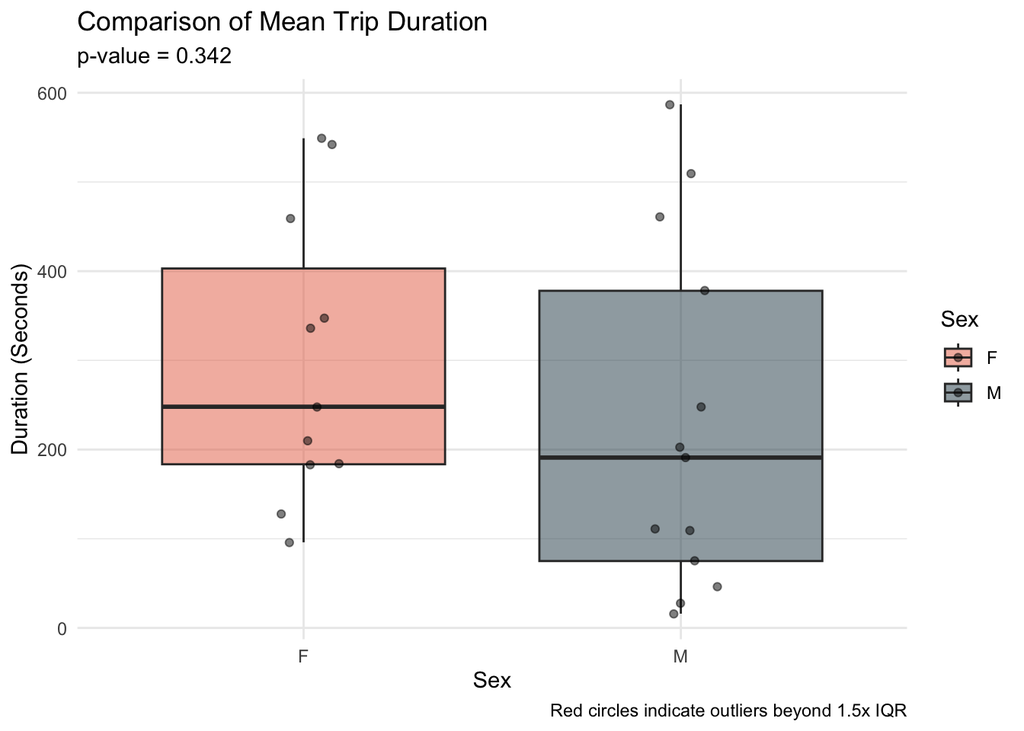

```r
# Visualization of the Test
ggplot(birds_clean, aes(x = Sex, y = TripSec, fill = Sex)) +
  geom_boxplot(alpha = 0.5, outlier.color = "red", outlier.shape = 1) +
  geom_jitter(width = 0.1, alpha = 0.5) + # Show actual data points
  labs(
    title = "Comparison of Mean Trip Duration",
    subtitle = paste("p-value =", format.pval(t_test_result$p.value, digits = 3)),
    caption = "Red circles indicate outliers beyond 1.5x IQR",
    y = "Duration (Seconds)"
  ) +
  scale_fill_manual(values = c("F" = "#E76F51", "M" = "#264653"))
```

**Interpretation:** If the p-value is < 0.05, we reject the null hypothesis and conclude there is a significant difference in parental behavior. (See subtitle for exact value).